# Granger Causality

Michiel van Eldik

10/13/2020

## **The Concept**

A vareiable *x* is **Granger causing** variable *y* if knowing the past of *x* improves our forecast of *y* based on the past of *y*. In other words, a signal *x* Granger causes a signal *y* if past values of *x* contain information that help to predict *y* above and beyond the information contained in past values of *y* alone.

Granger defined the causality relationship in two principles: * The cause happens prior to the effect * The cause has unique information about the future values of its effect.

### **Choice of number of lags**

The choice of an appropriate number of lags to include is important. It requires a good understanding of the situation at hand. What is reasonable?

### **Granger Causality in marketing**

- What marketing actions drive performance?
- What social media metrics drive performance? (heavily debated issue)
- Does offline marketing spending drive online marketing?
- Do online social media metrics drive offline marketing?
- Do manager base their marketing on performance feedback?
  - positive feedback = better performance, better budget
  - negative feedback = lower performance, higher need to invest
- Do competitors base their decisions on each others’ actions?

## **The Case**

A major European railway company wants to investigate the drivers of public transport usage. There are 2 types of travel:

- Ticket-based: occasional, leisure oriented
- Pass-based: regular, work-oriented

What are the possible drivers?

- Stepping stone theory: first tricket based, then moving to pass based
- Spill over effect: pass-based travellers “advertising” to ticket-based travellers
- Feedback effects through customer satisfaction

The marketing efforts are:

- Advertising
- Promotional actions through the own channel
- retailers promotions

Control variables:

- Gasoline prices
- Trend
- Seasonality

```r
library(lmtest)
library(vars)
railways.df <-read.csv("../SLIM0607Railways.csv")
```

### **Plotting the variables**

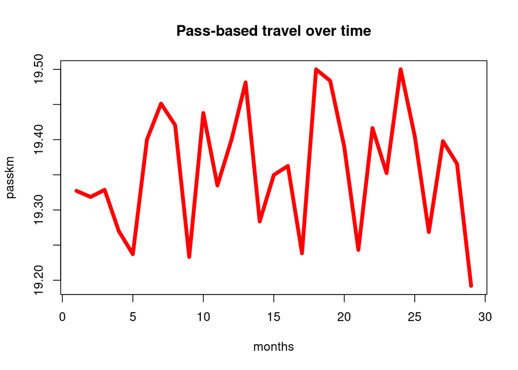

```r
plot(railways.df[,c(1)],railways.df[,c(2)], type="l", col="red", lwd=5, xlab="months", ylab="passkm", main="Pass-based travel over time")
```

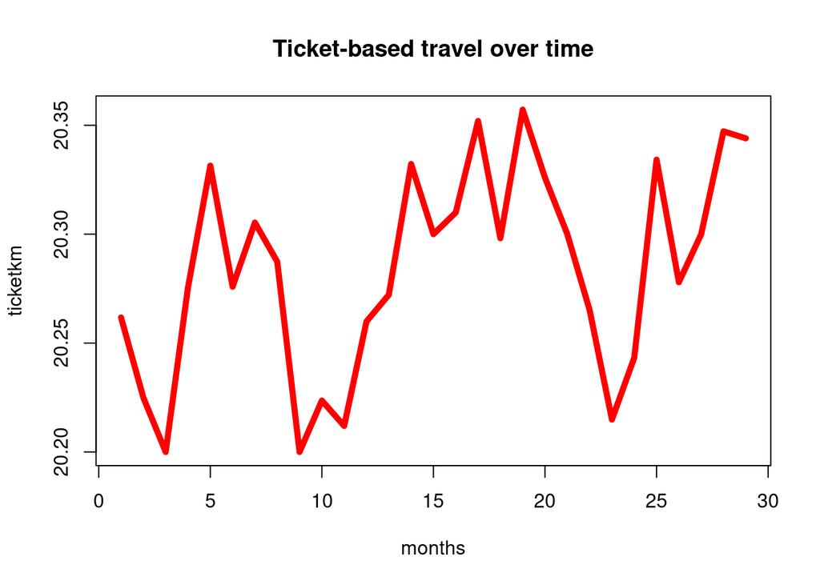

```r
plot(railways.df[,c(1)],railways.df[,c(3)], type="l", col="red", lwd=5, xlab="months", ylab="ticketkm", main="Ticket-based travel over time")
```

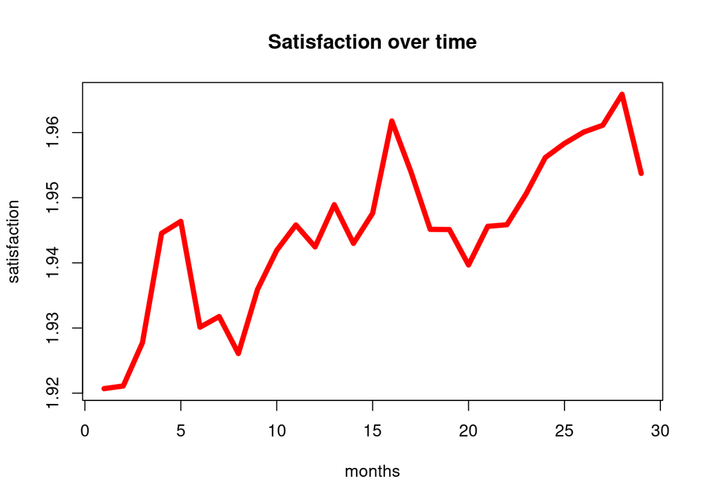

```r
plot(railways.df[,c(1)],railways.df[,c(4)], type="l", col="red", lwd=5, xlab="months", ylab="satisfaction", main="Satisfaction over time")
```

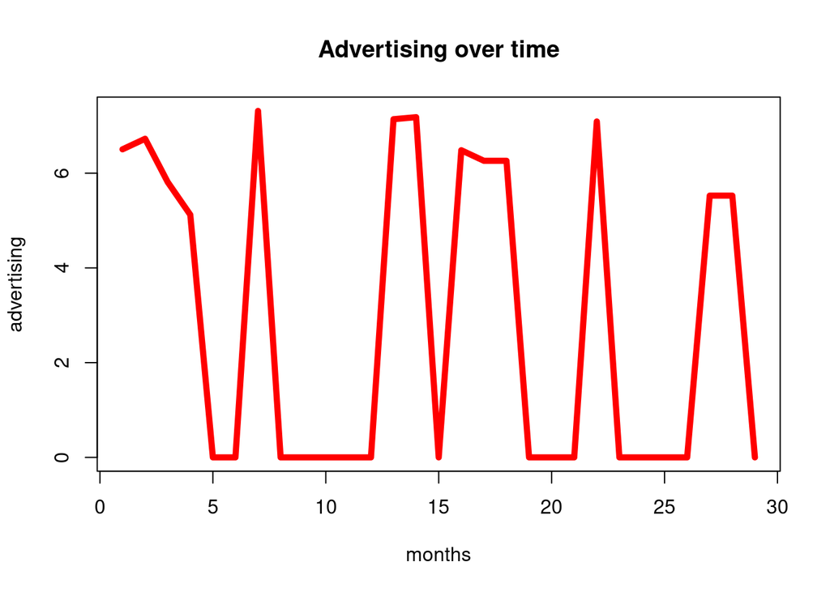

```r
plot(railways.df[,c(1)],railways.df[,c(6)], type="l", col="red", lwd=5, xlab="months", ylab="advertising", main="Advertising over time")
```

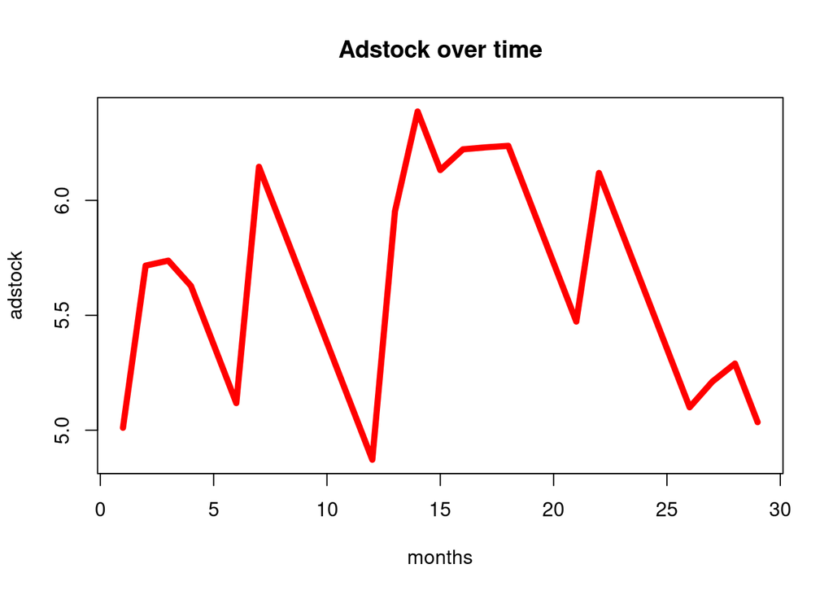

```r
plot(railways.df[,c(1)],railways.df[,c(11)], type="l", col="red", lwd=5, xlab="months", ylab="adstock", main="Adstock over time")
```

### **Which series to test?**

- Ticket-based travle, pass-based travel, and satisfaction may all influence each other. These series shopuld be tested!
- In our case, advertising and promotion actions are decided at the beginning of the year. Not influenced by performance feedback

#### **y = pass-based, x = ticket-based**

Judging fromt he output below, there is some evidence that Granger Causality is present at 6 to 8 lags.

```r
grangertest(LNKMABOFIX2~LNKMLOSFIX2, order = 2, data = railways.df)
```

```
## Granger causality test
##
## Model 1: LNKMABOFIX2 ~ Lags(LNKMABOFIX2, 1:2) + Lags(LNKMLOSFIX2, 1:2)
## Model 2: LNKMABOFIX2 ~ Lags(LNKMABOFIX2, 1:2)
##   Res.Df Df      F Pr(>F)
## 1     22
## 2     24 -2 0.6045 0.5552
```

```r
grangertest(LNKMABOFIX2~LNKMLOSFIX2, order = 4, data = railways.df)
```

```
## Granger causality test
##
## Model 1: LNKMABOFIX2 ~ Lags(LNKMABOFIX2, 1:4) + Lags(LNKMLOSFIX2, 1:4)
## Model 2: LNKMABOFIX2 ~ Lags(LNKMABOFIX2, 1:4)
##   Res.Df Df      F Pr(>F)
## 1     16
## 2     20 -4 1.7244 0.1938
```

```r
grangertest(LNKMABOFIX2~LNKMLOSFIX2, order = 6, data = railways.df)
```

```
## Granger causality test
##
## Model 1: LNKMABOFIX2 ~ Lags(LNKMABOFIX2, 1:6) + Lags(LNKMLOSFIX2, 1:6)
## Model 2: LNKMABOFIX2 ~ Lags(LNKMABOFIX2, 1:6)
##   Res.Df Df      F  Pr(>F)
## 1     10
## 2     16 -6 3.1901 0.05118 .
## ---
## Signif. codes:  0 '***' 0.001 '**' 0.01 '*' 0.05 '.' 0.1 ' ' 1
```

```r
grangertest(LNKMABOFIX2~LNKMLOSFIX2, order = 8, data = railways.df)
```

```
## Granger causality test
##
## Model 1: LNKMABOFIX2 ~ Lags(LNKMABOFIX2, 1:8) + Lags(LNKMLOSFIX2, 1:8)
## Model 2: LNKMABOFIX2 ~ Lags(LNKMABOFIX2, 1:8)
##   Res.Df Df      F  Pr(>F)
## 1      4
## 2     12 -8 4.4121 0.08409 .
## ---
## Signif. codes:  0 '***' 0.001 '**' 0.01 '*' 0.05 '.' 0.1 ' ' 1
```

#### **y = pass-based, x = Satisfaction**

Judging fromt he output below, there is no statistical evidence that Satisfaction G-causes pass-based travel

```r
grangertest(LNKMABOFIX2~LNAOAVERAGE_2, order = 2, data = railways.df)
```

```
## Granger causality test
##
## Model 1: LNKMABOFIX2 ~ Lags(LNKMABOFIX2, 1:2) + Lags(LNAOAVERAGE_2, 1:2)
## Model 2: LNKMABOFIX2 ~ Lags(LNKMABOFIX2, 1:2)
##   Res.Df Df      F Pr(>F)
## 1     22
## 2     24 -2 2.3325 0.1206
```

```r
grangertest(LNKMABOFIX2~LNAOAVERAGE_2, order = 4, data = railways.df)
```

```
## Granger causality test
##
## Model 1: LNKMABOFIX2 ~ Lags(LNKMABOFIX2, 1:4) + Lags(LNAOAVERAGE_2, 1:4)
## Model 2: LNKMABOFIX2 ~ Lags(LNKMABOFIX2, 1:4)
##   Res.Df Df      F Pr(>F)
## 1     16
## 2     20 -4 2.2536 0.1088
```

```r
grangertest(LNKMABOFIX2~LNAOAVERAGE_2, order = 6, data = railways.df)
```

```
## Granger causality test
##
## Model 1: LNKMABOFIX2 ~ Lags(LNKMABOFIX2, 1:6) + Lags(LNAOAVERAGE_2, 1:6)
## Model 2: LNKMABOFIX2 ~ Lags(LNKMABOFIX2, 1:6)
##   Res.Df Df      F Pr(>F)
## 1     10
## 2     16 -6 1.9992 0.1591
```

```r
grangertest(LNKMABOFIX2~LNAOAVERAGE_2, order = 8, data = railways.df)
```

```
## Granger causality test
##
## Model 1: LNKMABOFIX2 ~ Lags(LNKMABOFIX2, 1:8) + Lags(LNAOAVERAGE_2, 1:8)
## Model 2: LNKMABOFIX2 ~ Lags(LNKMABOFIX2, 1:8)
##   Res.Df Df      F Pr(>F)
## 1      4
## 2     12 -8 1.8654 0.2862
```

#### **y = Ticket-based, x = pass-based**

Judging fromt he output below, there is no statistical evidence that Ticket-based is G-caused by pass-based

```r
grangertest(LNKMLOSFIX2~LNKMABOFIX2, order = 2, data = railways.df)
```

```
## Granger causality test
##
## Model 1: LNKMLOSFIX2 ~ Lags(LNKMLOSFIX2, 1:2) + Lags(LNKMABOFIX2, 1:2)
## Model 2: LNKMLOSFIX2 ~ Lags(LNKMLOSFIX2, 1:2)
##   Res.Df Df      F Pr(>F)
## 1     22
## 2     24 -2 1.0705   0.36
```

```r
grangertest(LNKMLOSFIX2~LNKMABOFIX2, order = 4, data = railways.df)
```

```
## Granger causality test
##
## Model 1: LNKMLOSFIX2 ~ Lags(LNKMLOSFIX2, 1:4) + Lags(LNKMABOFIX2, 1:4)
## Model 2: LNKMLOSFIX2 ~ Lags(LNKMLOSFIX2, 1:4)
##   Res.Df Df      F Pr(>F)
## 1     16
## 2     20 -4 0.6623 0.6271
```

```r
grangertest(LNKMLOSFIX2~LNKMABOFIX2, order = 6, data = railways.df)
```

```
## Granger causality test
##
## Model 1: LNKMLOSFIX2 ~ Lags(LNKMLOSFIX2, 1:6) + Lags(LNKMABOFIX2, 1:6)
## Model 2: LNKMLOSFIX2 ~ Lags(LNKMLOSFIX2, 1:6)
##   Res.Df Df      F Pr(>F)
## 1     10
## 2     16 -6 1.8309 0.1899
```

```r
grangertest(LNKMLOSFIX2~LNKMABOFIX2, order = 8, data = railways.df)
```

```
## Granger causality test
##
## Model 1: LNKMLOSFIX2 ~ Lags(LNKMLOSFIX2, 1:8) + Lags(LNKMABOFIX2, 1:8)
## Model 2: LNKMLOSFIX2 ~ Lags(LNKMLOSFIX2, 1:8)
##   Res.Df Df      F Pr(>F)
## 1      4
## 2     12 -8 1.2972 0.4265
```

#### **y = Ticket-based, x = Satisfaction**

Judging fromt he output below, there is statistical evidence that Ticket-based is G-caused by satisfaction.

```r
grangertest(LNKMLOSFIX2~LNAOAVERAGE_2, order = 2, data = railways.df)
```

```
## Granger causality test
##
## Model 1: LNKMLOSFIX2 ~ Lags(LNKMLOSFIX2, 1:2) + Lags(LNAOAVERAGE_2, 1:2)
## Model 2: LNKMLOSFIX2 ~ Lags(LNKMLOSFIX2, 1:2)
##   Res.Df Df      F  Pr(>F)
## 1     22
## 2     24 -2 3.1907 0.06071 .
## ---
## Signif. codes:  0 '***' 0.001 '**' 0.01 '*' 0.05 '.' 0.1 ' ' 1
```

```r
grangertest(LNKMLOSFIX2~LNAOAVERAGE_2, order = 4, data = railways.df)
```

```
## Granger causality test
##
## Model 1: LNKMLOSFIX2 ~ Lags(LNKMLOSFIX2, 1:4) + Lags(LNAOAVERAGE_2, 1:4)
## Model 2: LNKMLOSFIX2 ~ Lags(LNKMLOSFIX2, 1:4)
##   Res.Df Df      F  Pr(>F)
## 1     16
## 2     20 -4 3.1413 0.04378 *
## ---
## Signif. codes:  0 '***' 0.001 '**' 0.01 '*' 0.05 '.' 0.1 ' ' 1
```

```r
grangertest(LNKMLOSFIX2~LNAOAVERAGE_2, order = 6, data = railways.df)
```

```
## Granger causality test
##
## Model 1: LNKMLOSFIX2 ~ Lags(LNKMLOSFIX2, 1:6) + Lags(LNAOAVERAGE_2, 1:6)
## Model 2: LNKMLOSFIX2 ~ Lags(LNKMLOSFIX2, 1:6)
##   Res.Df Df      F Pr(>F)
## 1     10
## 2     16 -6 2.2573 0.1222
```

```r
grangertest(LNKMLOSFIX2~LNAOAVERAGE_2, order = 8, data = railways.df)
```

```
## Granger causality test
##
## Model 1: LNKMLOSFIX2 ~ Lags(LNKMLOSFIX2, 1:8) + Lags(LNAOAVERAGE_2, 1:8)
## Model 2: LNKMLOSFIX2 ~ Lags(LNKMLOSFIX2, 1:8)
##   Res.Df Df      F Pr(>F)
## 1      4
## 2     12 -8 1.7366 0.3115
```

#### **y = Satisfaction, x = Pass-based**

Judging fromt he output below, there is statistical evidence that satisfaction is G-caused by pass-based travel.

```r
grangertest(LNAOAVERAGE_2~LNKMABOFIX2, order = 2, data = railways.df)
```

```
## Granger causality test
##
## Model 1: LNAOAVERAGE_2 ~ Lags(LNAOAVERAGE_2, 1:2) + Lags(LNKMABOFIX2, 1:2)
## Model 2: LNAOAVERAGE_2 ~ Lags(LNAOAVERAGE_2, 1:2)
##   Res.Df Df      F Pr(>F)
## 1     22
## 2     24 -2 0.0999 0.9053
```

```r
grangertest(LNAOAVERAGE_2~LNKMABOFIX2, order = 4, data = railways.df)
```

```
## Granger causality test
##
## Model 1: LNAOAVERAGE_2 ~ Lags(LNAOAVERAGE_2, 1:4) + Lags(LNKMABOFIX2, 1:4)
## Model 2: LNAOAVERAGE_2 ~ Lags(LNAOAVERAGE_2, 1:4)
##   Res.Df Df      F  Pr(>F)
## 1     16
## 2     20 -4 3.0176 0.04947 *
## ---
## Signif. codes:  0 '***' 0.001 '**' 0.01 '*' 0.05 '.' 0.1 ' ' 1
```

```r
grangertest(LNAOAVERAGE_2~LNKMABOFIX2, order = 6, data = railways.df)
```

```
## Granger causality test
##
## Model 1: LNAOAVERAGE_2 ~ Lags(LNAOAVERAGE_2, 1:6) + Lags(LNKMABOFIX2, 1:6)
## Model 2: LNAOAVERAGE_2 ~ Lags(LNAOAVERAGE_2, 1:6)
##   Res.Df Df     F Pr(>F)
## 1     10
## 2     16 -6 2.237 0.1247
```

```r
grangertest(LNAOAVERAGE_2~LNKMABOFIX2, order = 8, data = railways.df)
```

```
## Granger causality test
##
## Model 1: LNAOAVERAGE_2 ~ Lags(LNAOAVERAGE_2, 1:8) + Lags(LNKMABOFIX2, 1:8)
## Model 2: LNAOAVERAGE_2 ~ Lags(LNAOAVERAGE_2, 1:8)
##   Res.Df Df      F Pr(>F)
## 1      4
## 2     12 -8 0.9589 0.5575
```

#### **y = Satisfaction, x = ticket-based**

Little evidence…

```r
grangertest(LNAOAVERAGE_2~LNKMLOSFIX2, order = 2, data = railways.df)
```

```
## Granger causality test
##
## Model 1: LNAOAVERAGE_2 ~ Lags(LNAOAVERAGE_2, 1:2) + Lags(LNKMLOSFIX2, 1:2)
## Model 2: LNAOAVERAGE_2 ~ Lags(LNAOAVERAGE_2, 1:2)
##   Res.Df Df      F  Pr(>F)
## 1     22
## 2     24 -2 2.6429 0.09362 .
## ---
## Signif. codes:  0 '***' 0.001 '**' 0.01 '*' 0.05 '.' 0.1 ' ' 1
```

```r
grangertest(LNAOAVERAGE_2~LNKMLOSFIX2, order = 4, data = railways.df)
```

```
## Granger causality test
##
## Model 1: LNAOAVERAGE_2 ~ Lags(LNAOAVERAGE_2, 1:4) + Lags(LNKMLOSFIX2, 1:4)
## Model 2: LNAOAVERAGE_2 ~ Lags(LNAOAVERAGE_2, 1:4)
##   Res.Df Df      F Pr(>F)
## 1     16
## 2     20 -4 1.9375 0.1532
```

```r
grangertest(LNAOAVERAGE_2~LNKMLOSFIX2, order = 6, data = railways.df)
```

```
## Granger causality test
##
## Model 1: LNAOAVERAGE_2 ~ Lags(LNAOAVERAGE_2, 1:6) + Lags(LNKMLOSFIX2, 1:6)
## Model 2: LNAOAVERAGE_2 ~ Lags(LNAOAVERAGE_2, 1:6)
##   Res.Df Df      F Pr(>F)
## 1     10
## 2     16 -6 1.3094 0.3362
```

```r
grangertest(LNAOAVERAGE_2~LNKMLOSFIX2, order = 8, data = railways.df)
```

```
## Granger causality test
##
## Model 1: LNAOAVERAGE_2 ~ Lags(LNAOAVERAGE_2, 1:8) + Lags(LNKMLOSFIX2, 1:8)
## Model 2: LNAOAVERAGE_2 ~ Lags(LNAOAVERAGE_2, 1:8)
##   Res.Df Df      F Pr(>F)
## 1      4
## 2     12 -8 0.4102 0.8681
```